# (M) Disease Incidence Datasets and hsCRP

Randy Truong

2022-12-25

# Introduction

In this study, we seek to analyze the relationships between disease incidence and rates of hsCRP (C-Reactive Protein) among individuals of different races. More specifically, we will be analyzing datasets from Asians, Hispanics, (Non-Hispanic) Whites, and (Non-Hispanic) Blacks. All of these datasets have been sourced from the **AddHealth** database.

## Preliminary Information

### Inflammation

Inflammation occurs in the human body in two different forms.

**Acute inflammation** occurs as an innate response to pathoegens, stressors, and injuries as a protective mechanism. Typically, symptoms of inflammation include fever, chills, and fatigue/loss of energy. Acute inflammation typically resolves in a timeframe of a few hours up to a few weeks.

**Chronic inflammation**, however, results from acute inflammation that has has not been completely eliminated from the immune system as well as frequent exposure to low magnitude stressors. The symptoms of chronic inflammation are similar to that of acute inflammation, except that they persist as opposed to being temporary.

Immune cells will undergo a process called cytokinesis which results in the secretion and creation of C-Reactive Protein from the liver.

### C-Reactive Protein

**C-Reactive Protein** (also known as CRP) is a non-volatile protein that is synthesized in response to the presence of cytokines. Measurement of CRP is conducted with **highly-sensitive assays**, which is why CRP is more commonly denoted as **hsCRP** (mg/L).

### C-Reactive Protein and Disease Incidence

## Methodology

```r
# Installing Packages
library(tidyverse)
library(readr)
```

# Data Setup

### Important Terminology:

CVD -> Cardiovascular Disease  
CRP -> C-Reactive Protein

```r
# Loading Data
mAsianDF <- read_csv("./Data/mData/M_Asian.csv")
mHispanicDF <- read_csv("./Data/mData/M_hispanic.csv")
mBlackDF <- read_csv("./Data/mData/M_non-hispanic_black.csv")
mWhiteDF <- read_csv("./Data/mData/M_non-hispanic_white.csv")
mDF <- read_csv("./Data/mData/allMales.csv")
```

# Filtering of Data Sets

In this dataset, all of the questions from the survey possessed only two difference choices: **0,** meaning “No”, and **1,** meaning “Yes.”

In the datasets, we mostly just care about the rows “Diagnosed with CVD” (1),  
“Ever diagnosed with diabetes W5” (11), “log10(hsCRP) W4” (24), “High hsCRP (>3 mg/L) W4” (25), and “Observations” (34).

```r
# Adding "Race" column
# Filtering rows
mAsianDFClean <- mutate(mAsianDF, Race = "Asian") %>%
  slice(1, 11, 23, 24, 25, 34)

mHispanicDFClean <- mutate(mHispanicDF, Race = "Hispanic") %>%
  slice(1, 11, 23, 24, 25, 34)

mBlackDFClean <- mutate(mBlackDF, Race = "Black") %>%
  slice(1, 11, 23, 24, 25, 34)

mWhiteDFClean <- mutate(mWhiteDF, Race = "White") %>%
  slice(1, 11, 23, 24, 25, 34)

mDFClean <- mutate(mDF, Race = "All") %>%
  slice(1, 11, 23, 24, 25, 34)
```

```r
# Merging DFs
raceList1 <- rbind(mAsianDFClean, mHispanicDFClean)
raceList2 <- rbind(mBlackDFClean, mWhiteDFClean)
raceList3 <- rbind(raceList1, raceList2)

finalRaceListM <- rbind(raceList3, mDFClean)
```

# Data Visualization

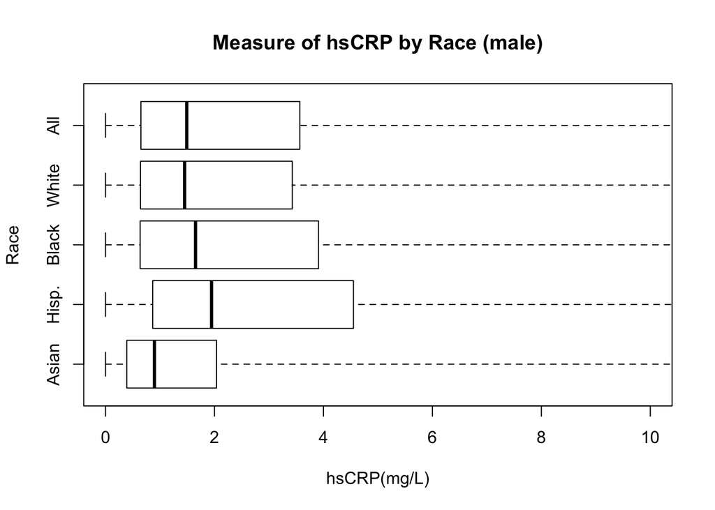

```r
# Boxplot for measuring average amounts of CRP among the surveyed

# Filtering to CRP rows
finalRaceListM_CRP <- finalRaceListM %>%
  slice(3, 9, 15, 21, 27)

# Creating 5-Number Summary Data Object
mStats <- list(stats=t(cbind(finalRaceListM_CRP$Minimum,
                      finalRaceListM_CRP$`Percentile 25`,
                      finalRaceListM_CRP$Median,
                      finalRaceListM_CRP$`Percentile 75`,
                      finalRaceListM_CRP$Maximum)),
          n=c(finalRaceListM_CRP$Count[1],
              finalRaceListM_CRP$Count[2],
              finalRaceListM_CRP$Count[3],
              finalRaceListM_CRP$Count[4],
              finalRaceListM_CRP$Count[5]))

bxp(mStats, show.names = FALSE, main="Measure of hsCRP by Race (male)", ylab= "Race", xlab="hsCRP(mg/L)", ylim= c(0,10), horizontal = TRUE )
axis(2, at = 1:5, labels = c("Asian", "Hisp.", "Black", "White", "All"))
```

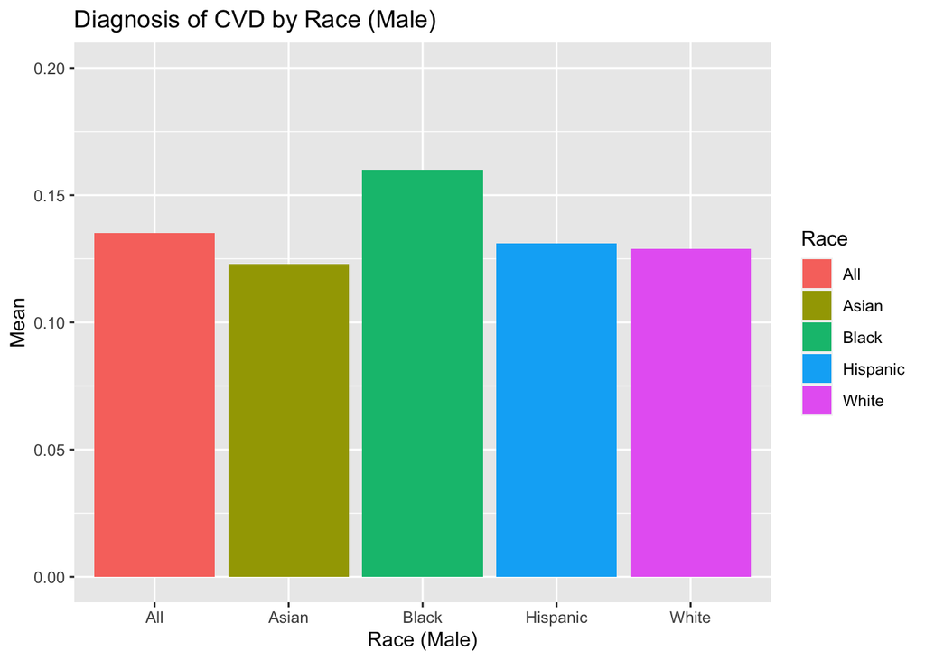

```r
# Bargraph for measuring frequency of Cardiovascular Disease (CVD) diagnoses

# Filtering the CVD diagnoses row
finalRaceListM_CVD <- finalRaceListM %>%
  slice(1, 7, 13, 19, 25)

# Building bargraph
finalRaceListM_CVD_bar <- ggplot(finalRaceListM_CVD, aes(x = Race, y=Mean, fill=Race)) +
  geom_bar(stat="identity") +
  ylim(0,0.2) +
  labs(title = "Diagnosis of CVD by Race (Male)", x = "Race (Male)")

finalRaceListM_CVD_bar
```

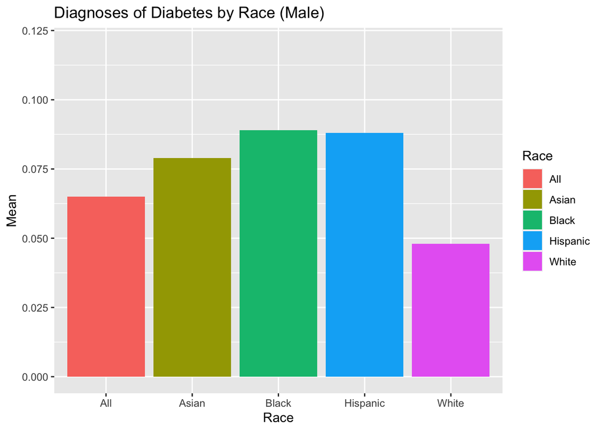

```r
# Bargraph for measuring frequency of diabetes diagnoses
finalRaceListM_D <- finalRaceListM %>%
  slice(2, 8, 14, 20, 26)

# Building bargraph
finalRaceListM_D_bar <- ggplot(finalRaceListM_D, aes(x = Race, y = Mean, fill=Race)) +
  geom_bar(stat="identity") +
  ylim(0,0.12) +
  labs(title="Diagnoses of Diabetes by Race (Male)")

finalRaceListM_D_bar
```